# Final Project

## Supervised Machine Learning Final Project

This project is about the sinking of the Titanic, one of the most infamous shipwrecks in history. I will use machine learning to create a model that predicts which passengers survived the Titanic shipwreck. The type of learning/algorithm is `Supervised Learning` which means that I use the patterns found in the train data to predict whether the passengers in test data survived. The type of machine learning task is `Classification` which is simply related to predicting a category of data. The goal of the project is to know what sorts of people were more likely to survive while learning `Data Cleaning`, `Exploratory Data Analysis`, and `Data Modeling` skills.

```python
import pandas as pd
import numpy as np
import matplotlib.pyplot as plt
import seaborn as sns
import statsmodels.formula.api as smf
import statsmodels.api as sm
from sklearn.tree import DecisionTreeClassifier
from sklearn.ensemble import RandomForestClassifier
from sklearn.svm import SVC
```

**Data**

The dataset is from a Kaggle competition (https://www.kaggle.com/competitions/titanic/overview), where the task is to predict survival given passenger data. I import the csv data using `pd.read_csv()` function and visually inspect the table using `.info()`.

```python
train = pd.read_csv('train.csv')
train.info()
```

```
<class 'pandas.core.frame.DataFrame'>
RangeIndex: 891 entries, 0 to 890
Data columns (total 12 columns):
 #   Column       Non-Null Count  Dtype
---  ------       --------------  -----
 0   PassengerId  891 non-null    int64
 1   Survived     891 non-null    int64
 2   Pclass       891 non-null    int64
 3   Name         891 non-null    object
 4   Sex          891 non-null    object
 5   Age          714 non-null    float64
 6   SibSp        891 non-null    int64
 7   Parch        891 non-null    int64
 8   Ticket       891 non-null    object
 9   Fare         891 non-null    float64
 10  Cabin        204 non-null    object
 11  Embarked     889 non-null    object
dtypes: float64(2), int64(5), object(5)
memory usage: 83.7+ KB
```

The train dataset is tabulated data with `891 samples/rows` and `12 features/columns`.

- **PassengerId**: Passenger Id. (Categorical)
- **Survival**: Survival. 0 = No, 1 = Yes. (Categorical)
- **Pclass**: Ticket class. 1 = 1st, 2 = 2nd, 3 = 3rd. (Numerical)
- **Name**: Passenger Name. (Categorical)
- **Sex**: Sex. (Categorical)
- **Age**: Age in years. (Numerical)
- **SibSp**: # of siblings / spouses aboard the Titanic. (Numerical)
- **Parch**: # of parents / children aboard the Titanic. (Numerical)
- **Ticket**: Ticket number. (Numerical)
- **Fare**: Passenger fare. (Numerical)
- **Cabin**: Cabin number. (Categorical)
- **Embarked**: Port of Embarkation. (Categorical)

```python
test = pd.read_csv('test.csv')
test.info()
```

```
<class 'pandas.core.frame.DataFrame'>
RangeIndex: 418 entries, 0 to 417
Data columns (total 11 columns):
 #   Column       Non-Null Count  Dtype
---  ------       --------------  -----
 0   PassengerId  418 non-null    int64
 1   Pclass       418 non-null    int64
 2   Name         418 non-null    object
 3   Sex          418 non-null    object
 4   Age          332 non-null    float64
 5   SibSp        418 non-null    int64
 6   Parch        418 non-null    int64
 7   Ticket       418 non-null    object
 8   Fare         417 non-null    float64
 9   Cabin        91 non-null     object
 10  Embarked     418 non-null    object
dtypes: float64(2), int64(4), object(5)
memory usage: 36.0+ KB
```

The test dataset is also tabulated data and it has `418 samples/rows` and `11 features/columns`.

**Data Cleaning**

First, I inspect the columns and the rows with `Null Values` in the training dataset to perform Data Cleaning.

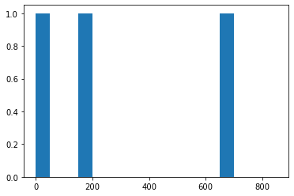

```python
counts = train.isnull().sum(axis=0)
counts = counts[counts>0]
null_counts = counts
bins = np.arange(0, 900, 50)
histogram = plt.hist(x=null_counts, bins=bins)
plt.show()
```

Based on the histogram above, I do not need to remove any row due to the lack of information.

```python
null_counts
```

```
Age         177
Cabin       687
Embarked      2
dtype: int64
```

After the inspection, these features are removed or imputed because of the explained reasons.

- **Name**: These are unique values and not relevant to the problem.
- **Ticket**: These are unique values and not relevant to the problem.
- **Cabin**: There are too many null values and the data cannot be imputed.
- **Age**: This feature has missing values but is relevant to the problem, so I replace missing values with imputed values.
- **Embarked**: The number of missing values of this feature is small, and I impute mode value in the feature.

```python
train = train.drop(columns = ['Name', 'Ticket', 'Cabin'])
train['Age'].fillna(train['Age'].mode()[0], inplace = True)
train['Embarked'].fillna(train['Embarked'].mode()[0], inplace = True)

train.info()
```

```
<class 'pandas.core.frame.DataFrame'>
RangeIndex: 891 entries, 0 to 890
Data columns (total 9 columns):
 #   Column       Non-Null Count  Dtype
---  ------       --------------  -----
 0   PassengerId  891 non-null    int64
 1   Survived     891 non-null    int64
 2   Pclass       891 non-null    int64
 3   Sex          891 non-null    object
 4   Age          891 non-null    float64
 5   SibSp        891 non-null    int64
 6   Parch        891 non-null    int64
 7   Fare         891 non-null    float64
 8   Embarked     891 non-null    object
dtypes: float64(2), int64(5), object(2)
memory usage: 62.8+ KB
```

```python
test = test.drop(columns = ['Name', 'Ticket', 'Cabin'])
test['Age'].fillna(test['Age'].mode()[0], inplace = True)
test['Embarked'].fillna(test['Embarked'].mode()[0], inplace = True)
test['Fare'].fillna(test['Fare'].mode()[0], inplace = True)

test.info()
```

```
<class 'pandas.core.frame.DataFrame'>
RangeIndex: 418 entries, 0 to 417
Data columns (total 8 columns):
 #   Column       Non-Null Count  Dtype
---  ------       --------------  -----
 0   PassengerId  418 non-null    int64
 1   Pclass       418 non-null    int64
 2   Sex          418 non-null    object
 3   Age          418 non-null    float64
 4   SibSp        418 non-null    int64
 5   Parch        418 non-null    int64
 6   Fare         418 non-null    float64
 7   Embarked     418 non-null    object
dtypes: float64(2), int64(4), object(2)
memory usage: 26.2+ KB
```

Now I have the train dataset with `891 samples/rows` and `9 features/columns`. The test set has `418 samples/rows` and `8 features/columns`.

Since I have two columns with string data, I convert their data type to numeric.

```python
train['Sex'].replace({'male':1, 'female':2}, inplace=True)
train['Embarked'].replace({'S':1, 'C':2, 'Q':3}, inplace=True)
train.info()
```

```
<class 'pandas.core.frame.DataFrame'>
RangeIndex: 891 entries, 0 to 890
Data columns (total 9 columns):
 #   Column       Non-Null Count  Dtype
---  ------       --------------  -----
 0   PassengerId  891 non-null    int64
 1   Survived     891 non-null    int64
 2   Pclass       891 non-null    int64
 3   Sex          891 non-null    int64
 4   Age          891 non-null    float64
 5   SibSp        891 non-null    int64
 6   Parch        891 non-null    int64
 7   Fare         891 non-null    float64
 8   Embarked     891 non-null    int64
dtypes: float64(2), int64(7)
memory usage: 62.8 KB
```

```python
test['Sex'].replace({'male':1, 'female':2}, inplace=True)
test['Embarked'].replace({'S':1, 'C':2, 'Q':3}, inplace=True)
test.info()
```

```
<class 'pandas.core.frame.DataFrame'>
RangeIndex: 418 entries, 0 to 417
Data columns (total 8 columns):
 #   Column       Non-Null Count  Dtype
---  ------       --------------  -----
 0   PassengerId  418 non-null    int64
 1   Pclass       418 non-null    int64
 2   Sex          418 non-null    int64
 3   Age          418 non-null    float64
 4   SibSp        418 non-null    int64
 5   Parch        418 non-null    int64
 6   Fare         418 non-null    float64
 7   Embarked     418 non-null    int64
dtypes: float64(2), int64(6)
memory usage: 26.2 KB
```

**Exploratory Data Analysis**

Now the datasets are ready to be used. Next, I visualize the correlation matrix using `seaborn.heatmap()` to check the correlation between features. I also inspect relationships between features using seaborn's `.pairplot()` function to draw a pairplot.

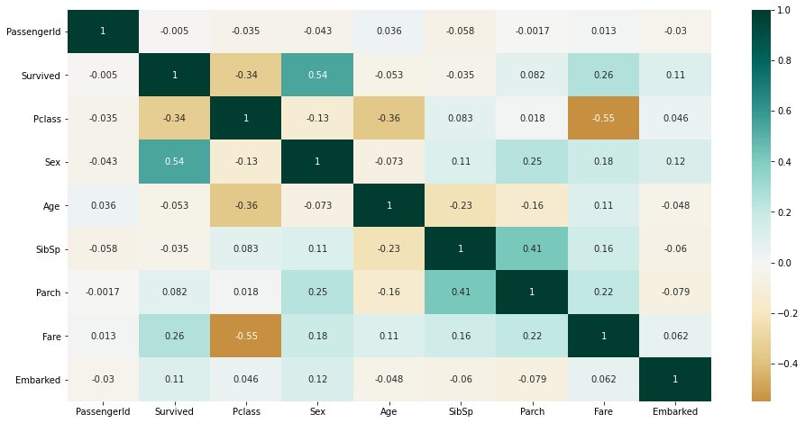

```python
plt.figure(figsize=(16,8))
sns.heatmap(train.corr(), center=0, cmap='BrBG', annot=True)
```

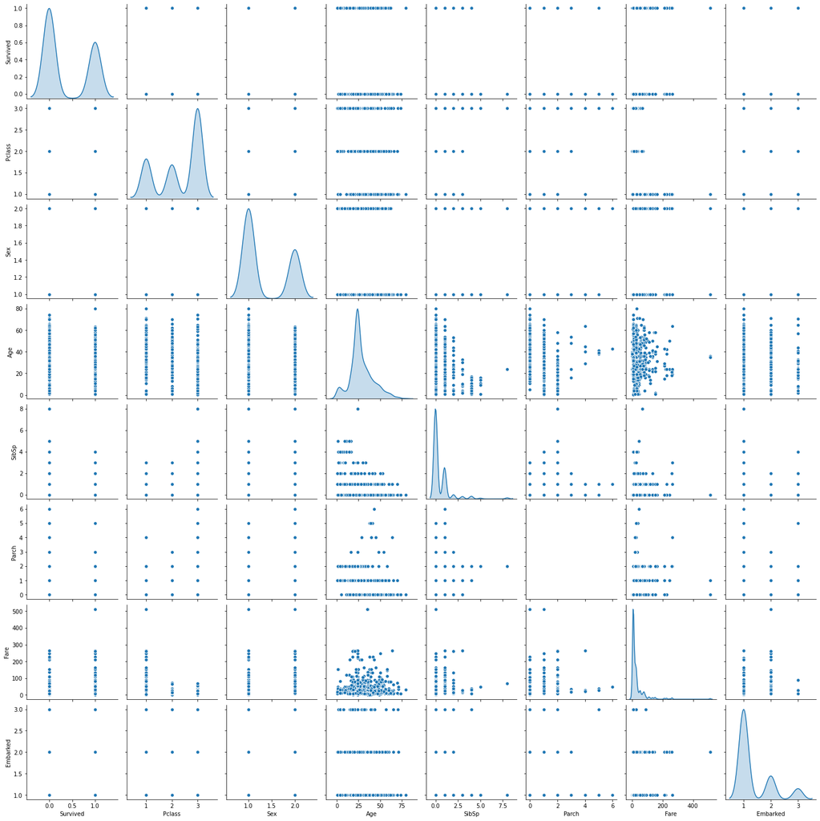

```python
cols_to_plot = train.iloc[:,1:]
sns.pairplot(cols_to_plot, diag_kind='kde')
```

Based on the correlation matrix and the pairplot, I get `Sex`, `Fare`, and `Pclass` as features those have correlationship with `Survived`. I visualize the data of those factors to find survival patterns.

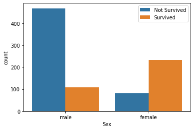

```python
Sex = ['male','female']
sns.countplot(data = train, x='Sex', hue='Survived')
plt.xticks(ticks = [0,1], labels = Sex)
plt.legend(['Not Survived', 'Survived'])
plt.show()
```

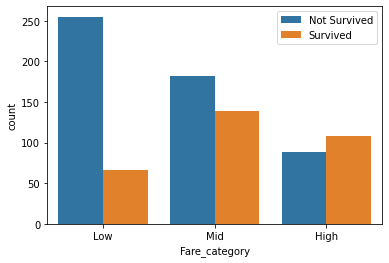

```python
train['Fare_category'] = pd.cut(train['Fare'], bins = [0,10,30,120], labels = ['Low','Mid','High'])
sns.countplot(data = train, x = 'Fare_category', hue = 'Survived')
plt.legend(['Not Survived', 'Survived'])
plt.show()
```

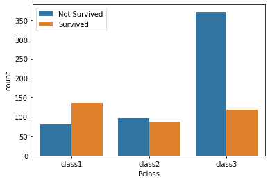

```python
Pclass = ['class1','class2','class3']
sns.countplot(data = train, x = 'Pclass', hue = 'Survived')
plt.xticks(ticks = [0,1,2], labels = Pclass)
plt.legend(['Not Survived', 'Survived'])
plt.show()
```

**Data Modeling - Decision Tree Classification**

The first modeling I perform is a `Decision Tree Classification` which is a non-parametric supervised learning method used for classification and regression.

```python
y = train['Survived']
X = pd.get_dummies(train.drop('Survived', axis=1))

tree_clf = DecisionTreeClassifier()
tree_clf.fit(X,y)
```

```
DecisionTreeClassifier(ccp_alpha=0.0, class_weight=None, criterion='gini',
                       max_depth=None, max_features=None, max_leaf_nodes=None,
                       min_impurity_decrease=0.0, min_impurity_split=None,
                       min_samples_leaf=1, min_samples_split=2,
                       min_weight_fraction_leaf=0.0, presort='deprecated',
                       random_state=None, splitter='best')
```

```python
print(tree_clf.score(X,y))
```

```
1.0
```

According to the result, the accuracy of Decision Tree Classification is `1.0`.

**Data Modeling - Random Forest Classifier**

A `Random Forest Classification` is a method that fits a number of decision tree classifiers on various sub-samples of the dataset and uses averaging to improve the predictive accuracy and control over-fitting.

```python
rnd_clf = RandomForestClassifier(n_estimators=100)
rnd_clf.fit(X,y)
```

```
RandomForestClassifier(bootstrap=True, ccp_alpha=0.0, class_weight=None,
                       criterion='gini', max_depth=None, max_features='auto',
                       max_leaf_nodes=None, max_samples=None,
                       min_impurity_decrease=0.0, min_impurity_split=None,
                       min_samples_leaf=1, min_samples_split=2,
                       min_weight_fraction_leaf=0.0, n_estimators=100,
                       n_jobs=None, oob_score=False, random_state=None,
                       verbose=0, warm_start=False)
```

```python
print(rnd_clf.score(X,y))
```

```
1.0
```

According to the result, the accuracy of Random Forest Classification is `1.0`.

**Data Modeling - Support Vector Machine**

Support vector machine is a supervised learning model with associated learning algorithms that analyze data for classification and regression analysis.

```python
svm_clf = SVC()
svm_clf.fit(X,y)
```

```
SVC(C=1.0, break_ties=False, cache_size=200, class_weight=None, coef0=0.0,
    decision_function_shape='ovr', degree=3, gamma='scale', kernel='rbf',
    max_iter=-1, probability=False, random_state=None, shrinking=True,
    tol=0.001, verbose=False)
```

```python
print(svm_clf.score(X,y))
```

```
0.6644219977553311
```

According to the result, the accuracy of Support Vector Machine is `0.66`.

**Make prediction based on Random Forest Classification**

Since I have the accuracy score of `1.0`, I choose `Random Forest Classifier` for the classification.

```python
features = ['Pclass', 'Sex', 'Fare']
X = pd.get_dummies(train[features])
X_test = pd.get_dummies(test[features])

model = RandomForestClassifier()
model.fit(X, y)
y_pred = model.predict(X_test)
```

**Hyperparameter Tuning - GridSearchCV**

```python
from sklearn.model_selection import GridSearchCV

param_grid = {'n_estimators': [25, 50, 100, 150], 'max_features': ['sqrt', 'log2', None], 'max_depth': [3, 6, 9],
              'max_leaf_nodes': [3, 6, 9],}
grid_search = GridSearchCV(RandomForestClassifier(), param_grid = param_grid)
grid_search.fit(X, y)
print(grid_search.best_estimator_)
```

```
RandomForestClassifier(bootstrap=True, ccp_alpha=0.0, class_weight=None,
                       criterion='gini', max_depth=9, max_features=None,
                       max_leaf_nodes=9, max_samples=None,
                       min_impurity_decrease=0.0, min_impurity_split=None,
                       min_samples_leaf=1, min_samples_split=2,
                       min_weight_fraction_leaf=0.0, n_estimators=25,
                       n_jobs=None, oob_score=False, random_state=None,
                       verbose=0, warm_start=False)
```

```python
model_grid = RandomForestClassifier(max_depth=9, max_features=None, max_leaf_nodes=9, n_estimators=25)
model_grid.fit(X, y)
y_pred_grid = model.predict(X_test)
```

```python
output = pd.DataFrame({'PassengerId': test.PassengerId, 'Survived': y_pred_grid})
print(output)
```

```
     PassengerId  Survived
0            892         0
1            893         1
2            894         0
3            895         0
4            896         1
..           ...       ...
413         1305         0
414         1306         1
415         1307         0
416         1308         0
417         1309         0

[418 rows x 2 columns]
```

**K-Fold Cross Validation**

`K-fold cross-validation` is used to assess the performance of a machine learning model and to estimate its generalization ability.

```python
def plot_roc_curve(fprs, tprs):

    tprs_interp = []
    aucs = []
    mean_fpr = np.linspace(0, 1, 100)
    f, ax = plt.subplots(figsize=(14,10))

    for i, (fpr, tpr) in enumerate(zip(fprs, tprs)):
        tprs_interp.append(np.interp(mean_fpr, fpr, tpr))
        tprs_interp[-1][0] = 0.0
        roc_auc = auc(fpr, tpr)
        aucs.append(roc_auc)
        ax.plot(fpr, tpr, lw=1, alpha=0.3,
                 label='ROC fold %d (AUC = %0.2f)' % (i, roc_auc))

    plt.plot([0, 1], [0, 1], linestyle='--', lw=2, color='r',
             label='Luck', alpha=.8)

    mean_tpr = np.mean(tprs_interp, axis=0)
    mean_tpr[-1] = 1.0
    mean_auc = auc(mean_fpr, mean_tpr)
    std_auc = np.std(aucs)
    ax.plot(mean_fpr, mean_tpr, color='b',
             label=r'Mean ROC (AUC = %0.2f $\pm$ %0.2f)' % (mean_auc, std_auc),
             lw=2, alpha=.8)

    std_tpr = np.std(tprs_interp, axis=0)
    tprs_upper = np.minimum(mean_tpr + std_tpr, 1)
    tprs_lower = np.maximum(mean_tpr - std_tpr, 0)
    ax.fill_between(mean_fpr, tprs_lower, tprs_upper, color='grey', alpha=.2,
                     label=r'$\pm$ 1 std. dev.')

    ax.set_xlim([-0.05, 1.05])
    ax.set_ylim([-0.05, 1.05])
    ax.set_xlabel('False Positive Rate')
    ax.set_ylabel('True Positive Rate')
    ax.set_title('Receiver operating characteristic')
    ax.legend(loc="lower right")
    plt.show()
    return (f, ax)

def compute_roc_auc(index):
    y_predict = model_grid.predict_proba(X.iloc[index])[:,1]
    fpr, tpr, thresholds = roc_curve(y.iloc[index], y_predict)
    auc_score = auc(fpr, tpr)
    return fpr, tpr, auc_score
```

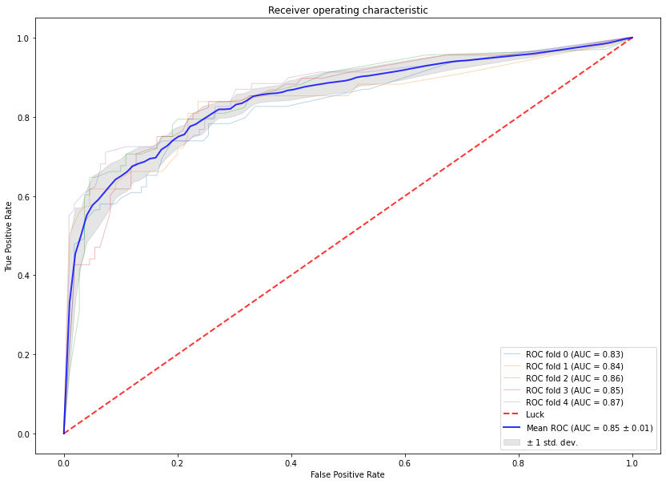

|  | AUC Train | AUC Test |
| --- | --- | --- |
| 0 | 0.888237 | 0.827404 |
| 1 | 0.875659 | 0.837767 |
| 2 | 0.877804 | 0.856952 |
| 3 | 0.877862 | 0.850401 |
| 4 | 0.875462 | 0.867438 |

```python
from sklearn.metrics import roc_curve
from sklearn.metrics import auc
from sklearn.model_selection import StratifiedKFold

cv = StratifiedKFold(n_splits = 5, random_state = 123, shuffle = True)
results = pd.DataFrame(columns = ['training_score', 'test_score'])
fprs, tprs, scores = [], [], []

for (train, test), i in zip(cv.split(X, y), range(5)):
    model_grid.fit(X.iloc[train], y.iloc[train])
    _, _, auc_score_train = compute_roc_auc(train)
    fpr, tpr, auc_score = compute_roc_auc(test)
    scores.append((auc_score_train, auc_score))
    fprs.append(fpr)
    tprs.append(tpr)

plot_roc_curve(fprs, tprs);
pd.DataFrame(scores, columns=['AUC Train', 'AUC Test'])
```

**Discussion and Conclusion**

During the project, I have done `Exploratory Data Analysis` which includes inspecting, cleaning, and performing visualization of the dataset. With the Titanic Passenger dataset, I cleaned both train and test dataset to make them ready to be analyzed and predicted (dropping features, replacing null values, and converting data type). And then, I generated a correlation matrix, a pairplot, and histograms to find best predictors and their patterns. After using classifiers for the problem (Decision Tree Classifier, Random Forest Classifier, and Support Vector Machine), I chose Random Forest Classifier as a model for the problem. I found the best parameters by doing GridSearchCv and updated the model with the parameters. After getting the predicted output, I did cross validation to assess the performance.

Most process has worked properly but something didn't because there was a lot of missing data. To improve the performance, I could use different way to impute values or select another features which represent better.